# Week3 : LOF

Harsha R S

### Installing the packages

```r
install.packages("DMwR")
install.packages("Rlof")
install.packages("outliers")
```

### Loading the Packages

```r
library(Rlof)
library(DMwR)
library(outliers)
```

## Method 1

### Loading the data

```r
m <- rnorm(100)
head(m)
```

```
[1]  0.33839398  0.51784458  0.95383444  0.03061192 -0.99566743  0.74660291
```

Next, we calculate LOF for each element in m vector. Here, we set 5 into argument k, the distance to calculate LOFs

```r
mlof <- lof(m, k=5)
head(mlof)
```

```
[1] 1.0140356 1.1263388 1.0281897 0.9405269 0.8912497 0.9200827
```

Next we look at the Density plot of outlier score that we got from lof function

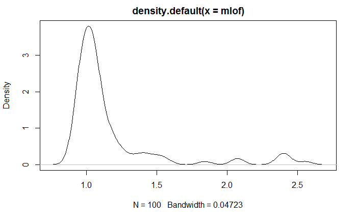

```r
plot(density(mlof))
```

According to above graph, we can observe the outlier is one tail.

Next, we check the probability distribution range of mlof.

```r
quantile(mlof,probs=seq(0.1,1,by=0.05))
```

```
      10%       15%       20%       25%       30%       35%       40%       45%       50%
0.9509858 0.9666407 0.9741462 0.9888523 1.0027539 1.0134533 1.0255407 1.0356737 1.0487415
      55%       60%       65%       70%       75%       80%       85%       90%       95%
1.0575614 1.0730862 1.0806393 1.1101640 1.1654838 1.1997617 1.3439800 1.5150696 2.0915230
     100%
2.5575041
```

Here, I set 95 percent’s value as a threshold to decide the value as an outlier. You may change it according to your requirement.

```r
thr=quantile(mlof, .95)
out_index=which(mlof>=thr)
m[out_index]
```

```
[1] -3.364331 -1.530373 -2.192991 -1.538983 -2.174333
```

### Use Grubbs tests for one outlier

Since the size of the generated dataset is 100x1, we pass only one column. If multiple columns are present, perform the test for each column

```r
grubbs.test(m, type = 10, opposite = FALSE, two.sided = FALSE)
```

```
    Grubbs test for one outlier

data:  m
G = 3.52750, U = 0.87304, p-value = 0.01371
alternative hypothesis: lowest value -3.3643313463091 is an outlier
```

Finally, we can plot the results to check the outliers in a chart

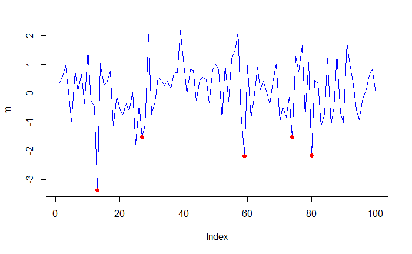

```r
plot(m, col="blue", type="l")
points(x=out_index, y=m[out_index], pch=19, col="red")
```

## Method 2

### Loading the data

```r
iris2 <- iris[,1:4]
head(iris2)
```

|  | Sepal.Length | Sepal.Width | Petal.Length | Petal.Width |
| --- | --- | --- | --- | --- |
| 1 | 5.1 | 3.5 | 1.4 | 0.2 |
| 2 | 4.9 | 3.0 | 1.4 | 0.2 |
| 3 | 4.7 | 3.2 | 1.3 | 0.2 |
| 4 | 4.6 | 3.1 | 1.5 | 0.2 |
| 5 | 5.0 | 3.6 | 1.4 | 0.2 |
| 6 | 5.4 | 3.9 | 1.7 | 0.4 |

Now we will obtain the outlier score with k= 5.

```r
outlier.scores <- lofactor(iris2, k=5)
```

Now we can obtain the top 5 outliers in the data set by typing the following commands

```r
outliers <- order(outlier.scores, decreasing=T)[1:5]
print(outliers)
```

```
[1]  42 107  23 110  63
```

You should now be able to identify the outliers.

The five outliers obtained in the output are the row numbers in the Iris2 data derived from the Iris data set.

To visualize the outliers with a biplot of the first two principal components use the following commands provided below:

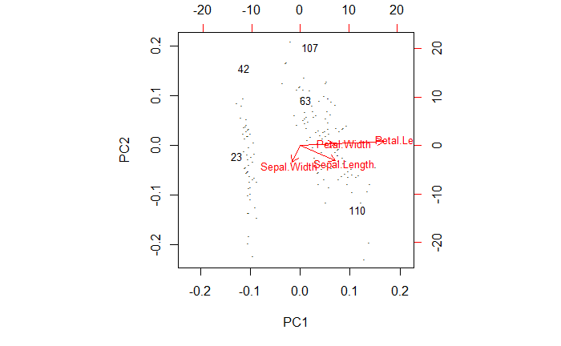

```r
n <- nrow(iris2)
labels <- 1:n
labels[-outliers] <- "."
biplot(prcomp(iris2), cex=.8, xlabs=labels)
```

Now we can use the pairs plot to visualize the outliers which are marked with a “+” sign in red by typing in the following commands:

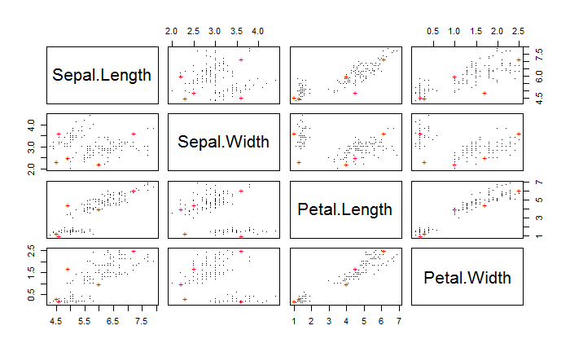

```r
pch <- rep(".", n)
pch[outliers] <- "+"
col <- rep("black", n)
col[outliers] <- "red"
pairs(iris2, pch=pch, col=col)
```

In each sub-graph, it mainly contains two group of points from different column and each outlier is clearly showed

### Parallel Computation of LOF Scores

```r
outlier.scores <- lof(iris2, k=c(5:10))
head(outlier.scores)
```

```
             5         6         7         8         9        10
[1,] 0.9979707 0.9974838 1.0138815 0.9786037 0.9902176 0.9749183
[2,] 1.0215881 0.9979364 0.9935776 0.9863154 1.0170826 0.9933587
[3,] 1.0545295 1.0169330 1.0053840 1.0352726 0.9855317 0.9971526
[4,] 0.9936177 1.0089740 0.9712264 0.9918824 1.0096213 1.0082478
[5,] 1.0049730 1.0157466 0.9729420 0.9868866 0.9983219 0.9976917
[6,] 1.2288344 1.1939532 1.1497786 1.1463403 1.1219691 1.1171744
```

> Source
- https://rpubs.com/maulikpatel/228336
- http://www.rdatamining.com/examples/outlier-detection
- https://www.datatechnotes.com/2017/12/outlier-detection-with-local-outlier.html
- https://rstudio-pubs-static.s3.amazonaws.com/216270_ccd62999b6504c22a390bb39fee22f39.html